# Formula 1 - Import and Tidying

```r
library(tidyverse)
library(lubridate)
```

## Circuits

```r
circuits <- readr::read_csv('https://raw.githubusercontent.com/rfordatascience/tidytuesday/master/data/2021/2021-09-07/circuits.csv')
```

No parsing errors.

Explore distribution of circuits by country

```r
circuits$country %>% n_distinct()
```

```
[1] 34
```

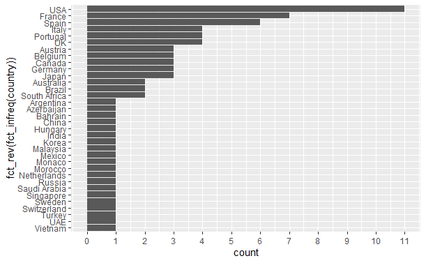

```r
circuits %>%
  group_by(country) %>%
  ggplot()+
  geom_bar(aes(x = fct_rev(fct_infreq(country))))+
  coord_flip()+
  scale_y_continuous(breaks = seq(0, 11, 1))
```

34 different countries have F1 circuits that have held Grand Prix races since 1950. USA has the most individual circuits with 11.

I wonder how many Grand Prix have been held in each country?

Possibility of a geo-spatial plot showing number of races held at each circuit or in each country maybe. Could also do a scatter plot comparing number of circuits and number of grand prix.

## Constructors

```r
constructors <- readr::read_csv('https://raw.githubusercontent.com/rfordatascience/tidytuesday/master/data/2021/2021-09-07/constructors.csv')
```

No parsing errors.

Explore distribution of constructors by nationality.

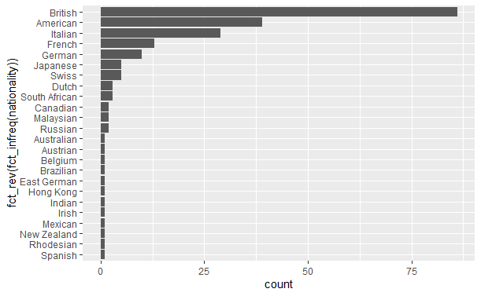

The British dominate the constructors.

Maybe look at constructors from each country over time.

## Drivers

```r
drivers <- readr::read_csv('https://raw.githubusercontent.com/rfordatascience/tidytuesday/master/data/2021/2021-09-07/drivers.csv')
```

No parsing errors.

Look at distribution of drivers

```r
drivers$nationality %>% n_distinct()
```

```
[1] 41
```

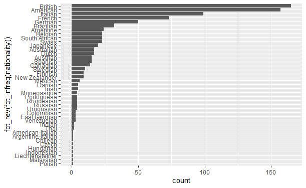

```r
drivers %>%
  ggplot()+
  geom_bar(aes(x = fct_rev(fct_infreq(nationality))))+
  coord_flip()
```

## Races

```r
races <- readr::read_csv('https://raw.githubusercontent.com/rfordatascience/tidytuesday/master/data/2021/2021-09-07/races.csv', na = "\\N")
```

```r
skimr::skim(races)
```

```
-- Data Summary ------------------------
                           Values
Name                       races
Number of rows             1058
Number of columns          8
_______________________
Column type frequency:
  character                2
  Date                     1
  difftime                 1
  numeric                  4
________________________
Group variables            None

-- Variable type: character --------------------------------------------------------
# A tibble: 2 x 8
  skim_variable n_missing complete_rate   min   max empty n_unique whitespace
* <chr>             <int>         <dbl> <int> <int> <int>    <int>      <int>
1 name                  0             1    16    29     0       50          0
2 url                   0             1    50    63     0     1058          0

-- Variable type: Date -------------------------------------------------------------
# A tibble: 1 x 7
  skim_variable n_missing complete_rate min        max        median     n_unique
* <chr>             <int>         <dbl> <date>     <date>     <date>        <int>
1 date                  0             1 1950-05-13 2021-12-12 1992-09-20     1058

-- Variable type: difftime ---------------------------------------------------------
# A tibble: 1 x 7
  skim_variable n_missing complete_rate min        max        median n_unique
* <chr>             <int>         <dbl> <drtn>     <drtn>     <time>    <int>
1 time                731         0.309 10800 secs 72000 secs 12:00        31

-- Variable type: numeric ----------------------------------------------------------
# A tibble: 4 x 11
  skim_variable n_missing complete_rate    mean     sd    p0   p25   p50   p75  p100
* <chr>             <int>         <dbl>   <dbl>  <dbl> <dbl> <dbl> <dbl> <dbl> <dbl>
1 raceId                0             1  531.   308.       1  265.  530.  794.  1073
2 year                  0             1 1991.    19.7   1950 1976  1992  2008   2021
3 round                 0             1    8.38   5.00     1    4     8    12     23
4 circuitId             0             1   22.2   17.3      1    9    18    32     77
  hist
* <chr>
1 ▇▇▇▇▇
2 ▃▅▆▆▇
3 ▇▆▆▃▁
4 ▇▅▂▁▁
```

```r
unique(races$time)
```

```
06:00:00
09:00:00
07:00:00
12:00:00
05:00:00
16:00:00
11:00:00
04:30:00
11:30:00
17:00:00
03:00:00
14:30:00
15:00:00
14:00:00
13:00:00
      NA
08:00:00
09:30:00
18:00:00
19:00:00
20:00:00
05:10:00
15:10:00
06:10:00
12:10:00
13:10:00
18:10:00
14:10:00
11:10:00
19:10:00
17:10:00
10:10:00
```

```r
typeof(races$time)
```

```
[1] "double"
```

Time parsed as character vector - due to “//N” which I presume is a missing value. Checked with API interface and confirms this. Best to sort this out on reading into R. I have added to code and it now parses this vector correctly as ‘difftime’.

```r
class(races$time)
```

```
[1] "hms"      "difftime"
```

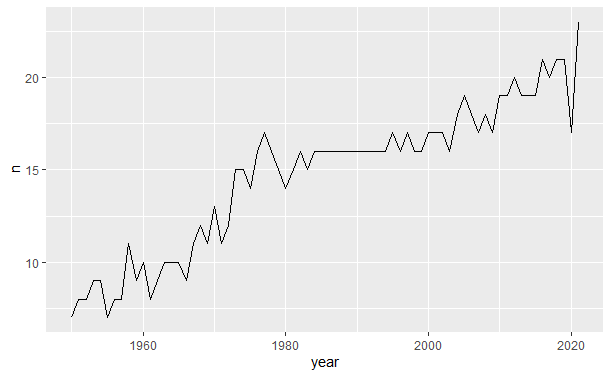

## Results

```r
results <- readr::read_csv('https://raw.githubusercontent.com/rfordatascience/tidytuesday/master/data/2021/2021-09-07/results.csv', na = "\\N")
```

```r
skimr::skim(results)
```

```
-- Data Summary ------------------------
                           Values
Name                       results
Number of rows             25220
Number of columns          18
_______________________
Column type frequency:
  character                2
  difftime                 1
  numeric                  15
________________________
Group variables            None

-- Variable type: character ---------------------------------------------------------
# A tibble: 2 x 8
  skim_variable n_missing complete_rate   min   max empty n_unique whitespace
* <chr>             <int>         <dbl> <int> <int> <int>    <int>      <int>
1 positionText          0         1         1     2     0       39          0
2 time              18496         0.267     4    11     0     6487          0

-- Variable type: difftime ----------------------------------------------------------
# A tibble: 1 x 7
  skim_variable  n_missing complete_rate min       max        median n_unique
* <chr>              <int>         <dbl> <drtn>    <drtn>     <time>    <int>
1 fastestLapTime     18443         0.269 3300 secs 12120 secs 01:30        85

-- Variable type: numeric -----------------------------------------------------------
# A tibble: 15 x 11
   skim_variable   n_missing complete_rate       mean         sd       p0      p25
 * <chr>               <int>         <dbl>      <dbl>      <dbl>    <dbl>    <dbl>
 1 resultId                0         1       12611.      7282.        1      6306.
 2 raceId                  0         1         518.       290.        1       287
 3 driverId                0         1         251.       258.        1        56
 4 constructorId           0         1          47.5       58.4       1         6
 5 number                  6         1.00       17.6       14.8       0         7
 6 grid                    0         1          11.2        7.27      0         5
 7 position            10762         0.573       7.90       4.79      1         4
 8 positionOrder           0         1          12.9        7.74      1         6
 9 points                  0         1           1.80       4.03      0         0
10 laps                    0         1          45.8       30.0       0        21
11 milliseconds        18497         0.267 6237789.   1694242.   207071   5413850.
12 fastestLap          18443         0.269      42.3       17.0       2        32
13 rank                18249         0.276      10.5        6.19      0         5
14 fastestLapSpeed     18443         0.269     203.        21.3      89.5     192.
15 statusId                0         1          17.7       26.1       1         1
        p50      p75      p100 hist
 *    <dbl>    <dbl>     <dbl> <chr>
 1   12610.   18915.    25225  ▇▇▇▇▇
 2     503      762      1064  ▆▇▇▆▆
 3     158      347       854  ▇▃▂▁▂
 4      25       57       214  ▇▂▁▁▁
 5      15       23       208  ▇▁▁▁▁
 6      11       17        34  ▇▇▇▃▁
 7       7       11        33  ▇▆▂▁▁
 8      12       19        39  ▇▇▆▂▁
 9       0        2        50  ▇▁▁▁▁
10      52       66       200  ▅▇▁▁▁
11 5818420  6435304  15090540  ▁▇▃▁▁
12      45       54        85  ▂▃▇▆▁
13      10       16        24  ▇▇▇▇▂
14     204.     216.      257. ▁▁▂▇▂
15      11       14       139  ▇▁▁▁▁
```

Time parsed as character due to winners time + difference. > 1 lap behind then no time recorded i.e. NA. Possibly correct this to give a time for all finishers within 1 lap of the winner.

Work on single race to start with: most recent

```r
results1 <- results %>%
  mutate(time_behind = hms::hms(as.numeric(str_replace(time, "\\+", ""))),
         time_behind = hms(time_behind)) %>%
  mutate_at(vars(time), na_if, "^\\+") %>%
  mutate(time = hms(.$time))
```

## Constructor results

```r
constructor_results <- readr::read_csv('https://raw.githubusercontent.com/rfordatascience/tidytuesday/master/data/2021/2021-09-07/constructor_results.csv', na = "\\N")
```

```r
constructor_results$status %>% unique()
```

```
[1] NA  "D"
```

## Status

```r
status <- readr::read_csv('https://raw.githubusercontent.com/rfordatascience/tidytuesday/master/data/2021/2021-09-07/status.csv')
```

Look at status per race over a season - differences between teams

Check distribution of status

```r
results %>%
  group_by(statusId) %>%
  count() %>%
  arrange(desc(n)) %>%
  left_join(status)
```

| statusId | n | status |
| --- | --- | --- |
| 1 | 6719 | Finished |
| 11 | 3716 | +1 Lap |
| 5 | 2003 | Engine |
| 12 | 1574 | +2 Laps |
| 3 | 1033 | Accident |
| 81 | 1025 | Did not qualify |
| 4 | 816 | Collision |
| 6 | 799 | Gearbox |
| 20 | 790 | Spun off |
| 13 | 730 | +3 Laps |

[output cut: 125 more lines]

## Qualifying

```r
qualifying <- readr::read_csv('https://raw.githubusercontent.com/rfordatascience/tidytuesday/master/data/2021/2021-09-07/qualifying.csv', na = "\\N")
```

## Pitstops

```r
pit_stops <- readr::read_csv('https://raw.githubusercontent.com/rfordatascience/tidytuesday/master/data/2021/2021-09-07/pit_stops.csv', na = "\\N")
```

```r
test <- pit_stops %>%
  #filter(duration < 60) %>%
  mutate(seconds = milliseconds(milliseconds))
```

```r
skimr::skim(pit_stops)
```

```
-- Data Summary ------------------------
                           Values
Name                       pit_stops
Number of rows             8496
Number of columns          7
_______________________
Column type frequency:
  difftime                 1
  numeric                  6
________________________
Group variables            None

-- Variable type: difftime -----------------------------------------------------
# A tibble: 1 x 7
  skim_variable n_missing complete_rate min        max        median
* <chr>             <int>         <dbl> <drtn>     <drtn>     <drtn>
1 time                  0             1 47071 secs 79452 secs 55206.5 secs
  n_unique
*    <int>
1     6518

-- Variable type: numeric ------------------------------------------------------
# A tibble: 6 x 11
  skim_variable n_missing complete_rate     mean         sd      p0     p25
* <chr>             <int>         <dbl>    <dbl>      <dbl>   <dbl>   <dbl>
1 raceId                0             1   940.       66.0     841     881
2 driverId              0             1   487.      395.        1      17
3 stop                  0             1     1.77      0.923     1       1
4 lap                   0             1    25.1      14.5       1      13
5 duration              0             1    65.3     246.       12.9    21.9
6 milliseconds          0             1 65301.   245526.    12897   21893.
      p50     p75     p100 hist
*   <dbl>   <dbl>    <dbl> <chr>
1   937     993      1064  ▇▅▆▅▅
2   813     826       854  ▆▁▁▁▇
3     2       2         6  ▇▂▁▁▁
4    25      35        78  ▇▇▆▂▁
5    23.5    26.1    2077. ▇▁▁▁▁
6 23486.  26056.  2077164  ▇▁▁▁▁
```

Distribution of pit_stop duration

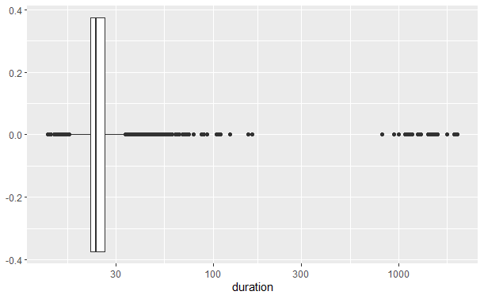

## Lap-times

```r
lap_times <- readr::read_csv('https://raw.githubusercontent.com/rfordatascience/tidytuesday/master/data/2021/2021-09-07/lap_times.csv')
```

[output not shown]

[output cut: 990 more lines]

```r
skimr::skim(lap_times)
```

```
-- Data Summary ------------------------
                           Values
Name                       lap_times
Number of rows             504917
Number of columns          7
_______________________
Column type frequency:
  difftime                 1
  numeric                  6
________________________
Group variables            None

-- Variable type: difftime -----------------------------------------------------
# A tibble: 1 x 7
  skim_variable n_missing complete_rate min       max         median n_unique
* <chr>             <int>         <dbl> <drtn>    <drtn>      <time>    <int>
1 time                  0             1 3300 secs 188280 secs 01:30       538

-- Variable type: numeric ------------------------------------------------------
# A tibble: 6 x 11
  skim_variable n_missing complete_rate     mean       sd      p0     p25
* <chr>             <int>         <dbl>    <dbl>    <dbl>   <dbl>   <dbl>
1 raceId                0             1   516.     413.       1     120
2 driverId              0             1   258.     361.       1      15
3 lap                   0             1    30.0     18.4      1      14
4 position              0             1     9.65     5.55     1       5
5 milliseconds          0             1 95561.   73943.   55404   82004
6 seconds               0             1    95.6     73.9     55.4    82.0
      p50     p75     p100 hist
*   <dbl>   <dbl>    <dbl> <chr>
1   342      943     1064  ▇▂▁▁▇
2    32      813      854  ▇▁▁▁▃
3    29       44       87  ▇▇▆▃▁
4     9       14       24  ▇▇▆▆▁
5 90630   102400  7507547  ▇▁▁▁▁
6    90.6    102.    7508. ▇▁▁▁▁
```

## Driver Standings

```r
driver_standings <- readr::read_csv('https://raw.githubusercontent.com/rfordatascience/tidytuesday/master/data/2021/2021-09-07/driver_standings.csv', cols(
  driverStandingsId = col_double(),
  raceId = col_double(),
  driverId = col_double(),
  points = col_double(),
  position = col_double(),
  positionText = col_character(),
  wins = col_double()
))
```

```
Error: `col_names` must be TRUE, FALSE or a character vector
```

[output not shown]

[output cut: 100 more lines]

## Constructor standings

```r
constructor_standings <- readr::read_csv('https://raw.githubusercontent.com/rfordatascience/tidytuesday/master/data/2021/2021-09-07/constructor_standings.csv')
```

[output not shown]

[output cut: 14 more lines]

## Seasons

```r
seasons <- readr::read_csv('https://raw.githubusercontent.com/rfordatascience/tidytuesday/master/data/2021/2021-09-07/seasons.csv')
```